# Correlations

Adam Raikes

March 13, 2017

# Purpose

The purpose of this slideshow is introduce the concept of correlations and to discuss how they function both mathematically and visually.

# Correlation

A correlation describes the **linear relationship between two continuous variables**. In practical terms, the correlation between two variables reflects the degree to which variables systematically change with each other.

# A Visual Example to Start

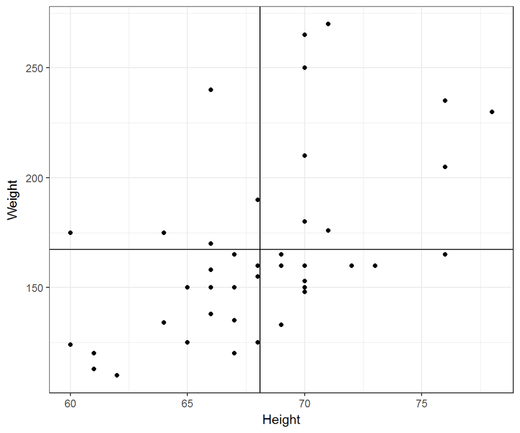

# Covariance

$$COV_{xy} = s_{xy} = \frac{\sum_{i=1}^{n}(x_i - \bar{x})(y_i - \bar{y})}{n - 1}$$

# Covariance

Some notes about covariance:

- If two variables are independent, then $s_{xy} = 0$.
- If $s_{xy} = 0$, the two variables are not necessarily independent.
- When there is a relationship, $s_{xy} \neq 0$ and the magnitude of the value reflects the scale of the measurements being made, not the magnitude of the relationship.
- The sign of $s_{xy}$ describes the direction of the relationship.

# Covariance example

```r
# Original covariance
cov(rt.data$Height, rt.data$Weight)
```

```
## [1] 92.82561
```

```r
# Scaling the values to metric
cov((rt.data$Height* 2.54), (rt.data$Weight * 0.454))
```

```
## [1] 107.0428
```

# Correlation

Because covariance depends on the original scale of the data, it is hard to interpret whether we have observed a weak or strong relationship in the data. Covariance can really only tell you if there is a relationship. However, correlation provides a means for interpretting.

$$cor_{xy} = r = \frac{s_{xy}}{s_xs_y}$$

# Correlation

By dividing by the product of the standard deviations, we make the our *correlation coefficient* scale-invariant (the scale of the values no longer matters). Correlations have useful properties:

- The range of correlations is $-1 \leq r \leq 1$.
- $r = 0$ indicates that there is no **linear** relationship in the data.
- The sign of $r$ indicates the direction of the relationship.
- The absolute value of the magnitude of $r$ indicates the strength of the relationship. Generally 0.3, 0.5, and 0.7 are the breakpoints for small, moderate, and strong relationships.

# Correlation

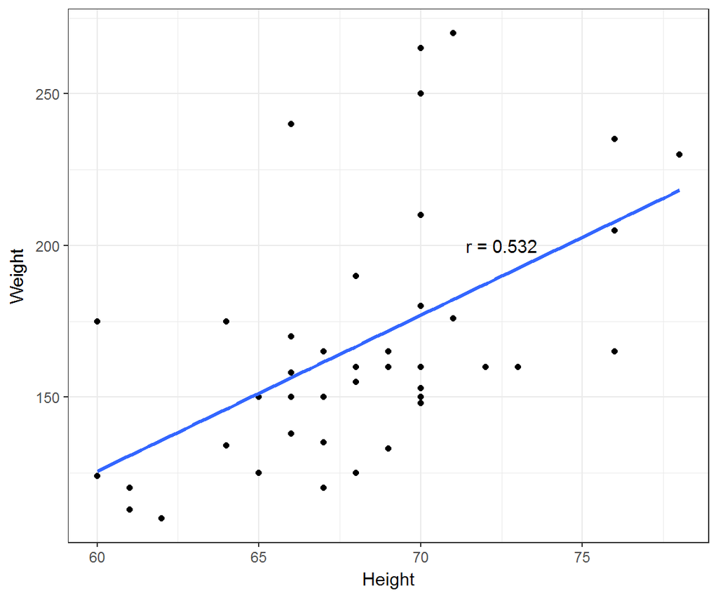

# Reaction Time and Movement Time

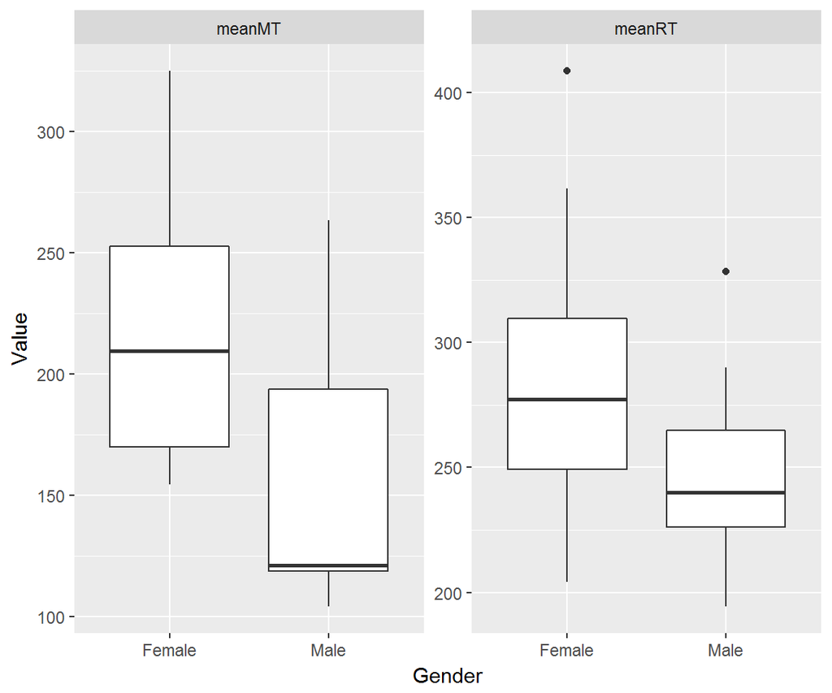

# Reaction Time and Movement Time

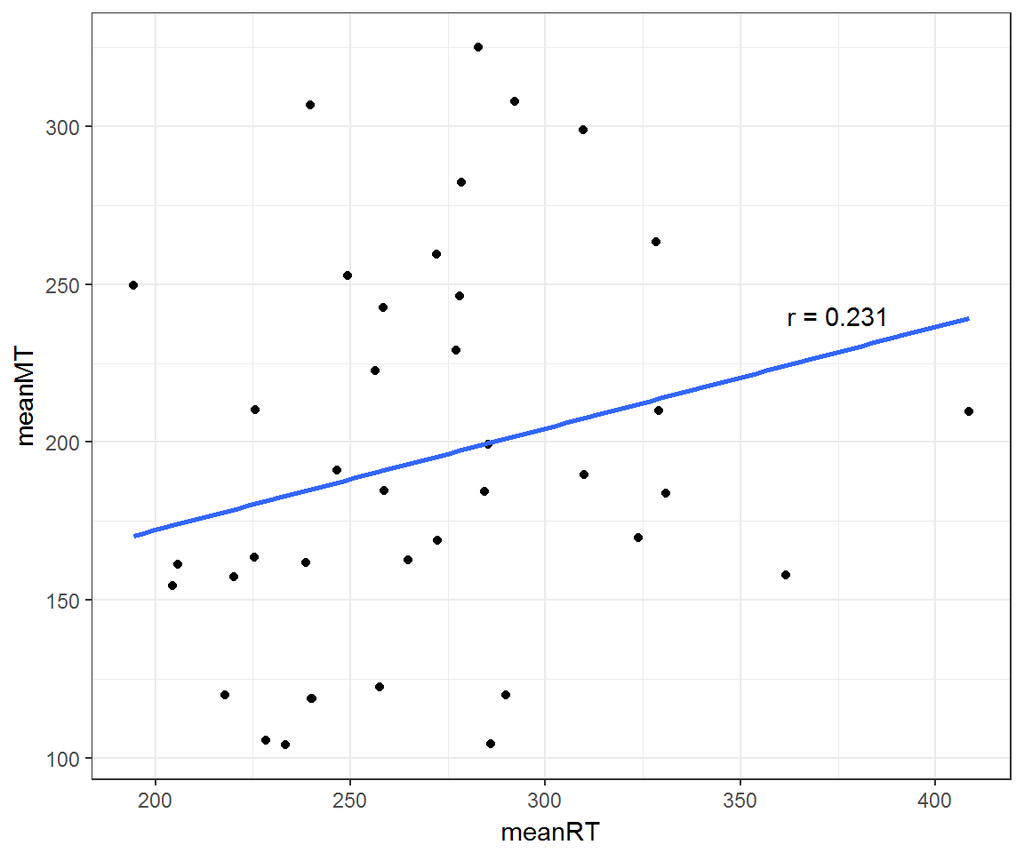

# Reaction Time and Movement Time

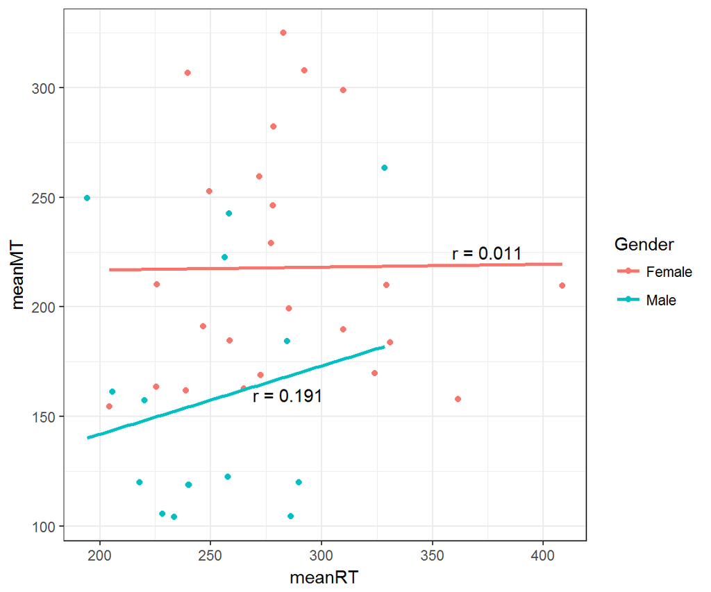

# Height and Movement Time

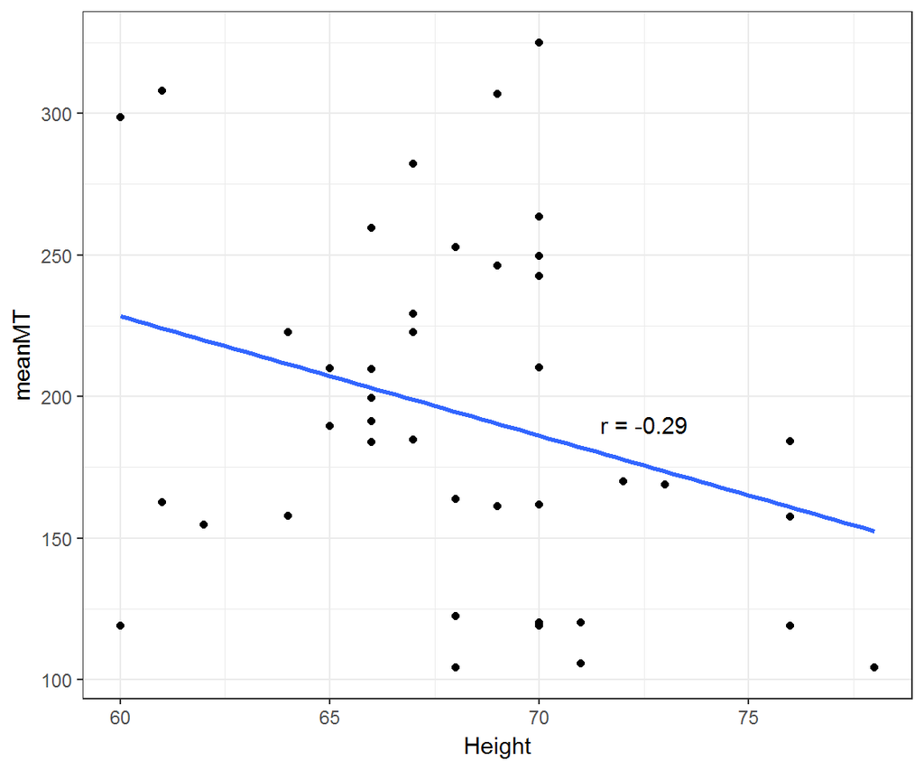

# Height and Movement Time

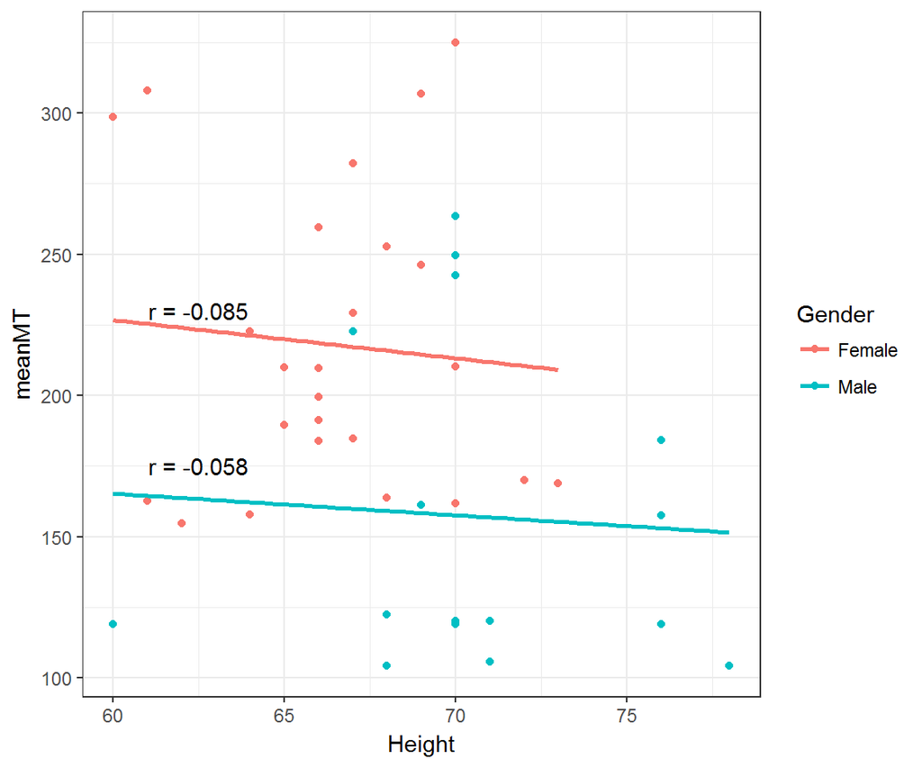

# Height and Reaction Time

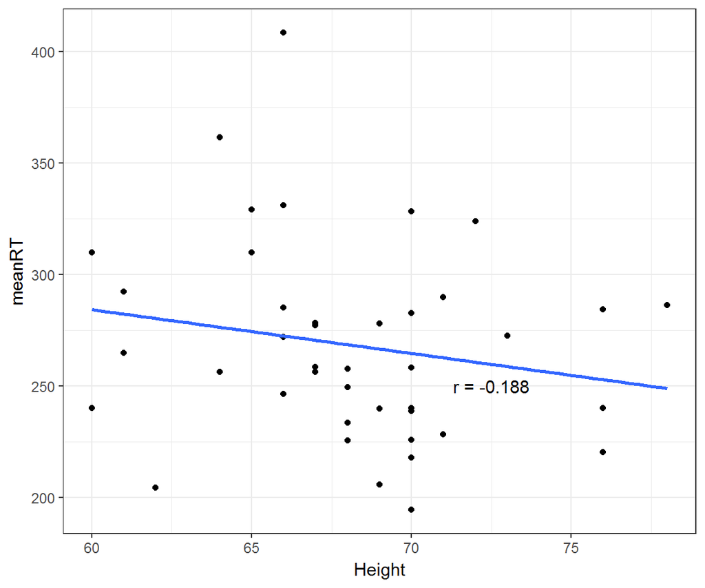

# Height and Reaction Time

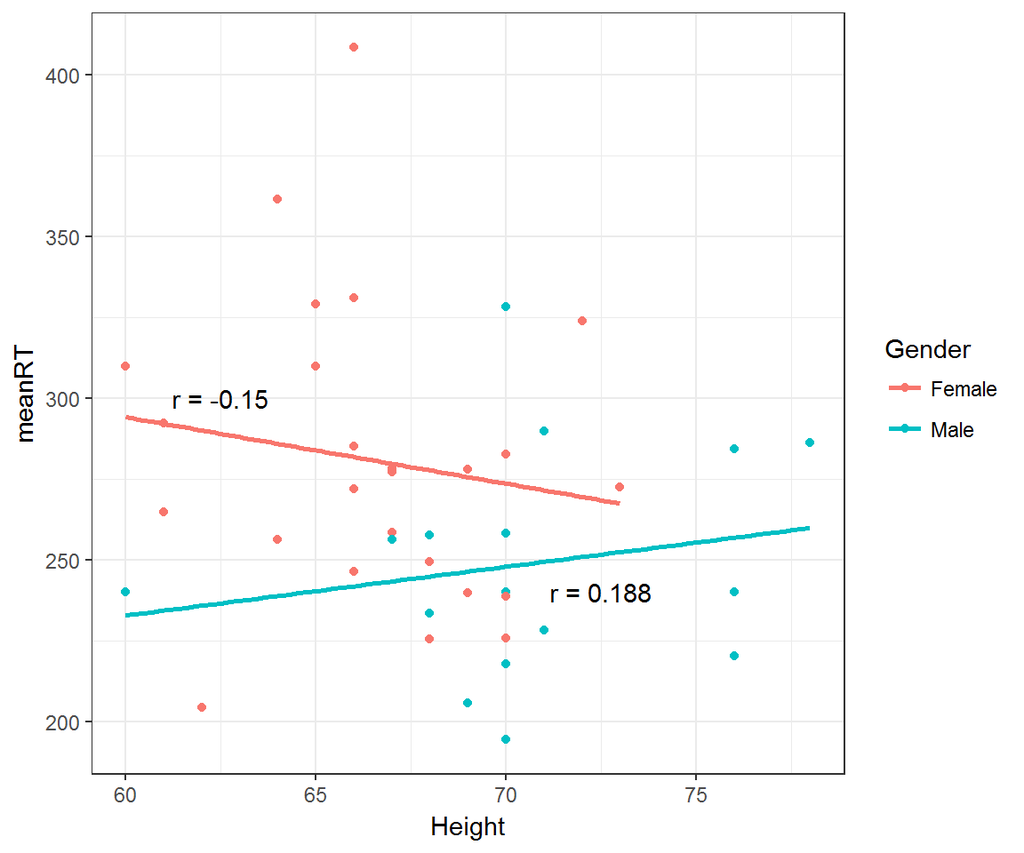